# Preregistered Analysis FamVoice REC

2024-08-09

This is the analysis for the project “The Voice Familiarity Benefit for Infant Phoneme Recognition”. Please note: the variable TestSpeaker (levels: 1, 2, 3) in this analysis document is called Test (levels: TrainVoiceTest, NovelVoiceTest, FamNonTrainVoiceTest) in the accompanying preregistration. TestSpeaker 1 corresponds to TrainVoiceTest, TestSpeaker2 corresponds to NovelVoiceTest, and TestSpeaker3 corresponds to FamNonTrainVoiceTest.

## Preparation: Pilot data and model checks

### Simulate some data

```r
source(here("code/R","01_data_simulation.R"), local = knitr::knit_global())
```

```r
head(dat_rec)
```

```
## # A tibble: 6 × 8
##   Subj   Group TestSpeaker   MMR mumDist nrSpeakersDaily sleepState    age
##   <fct>  <fct> <fct>       <dbl>   <dbl>           <dbl> <fct>       <dbl>
## 1 Subj01 fam   1           19.0    0.879           0.395 awake      -0.231
## 2 Subj01 fam   2           16.8    0.159           0.395 awake      -0.231
## 3 Subj01 fam   3           13.3   -1.01            0.395 awake      -0.231
## 4 Subj02 fam   1           -1.87  -1.03           -0.143 awake       0.173
## 5 Subj02 fam   2            1.78  -1.16           -0.143 awake       0.173
## 6 Subj02 fam   3            6.20   0.841          -0.143 awake       0.173
```

```r
summary(dat_rec)
```

```
##       Subj       Group    TestSpeaker      MMR             mumDist
##  Subj01 :  3   fam  :96   1:64        Min.   :-41.474   Min.   :-1.3753
##  Subj02 :  3   unfam:96   2:64        1st Qu.: -5.723   1st Qu.:-0.7773
##  Subj03 :  3              3:64        Median :  4.508   Median :-0.2218
##  Subj04 :  3                          Mean   :  4.780   Mean   : 0.0000
##  Subj05 :  3                          3rd Qu.: 15.141   3rd Qu.: 0.6040
##  Subj06 :  3                          Max.   : 48.012   Max.   : 3.6691
##  (Other):174
##  nrSpeakersDaily    sleepState       age
##  Min.   :-1.7548   asleep: 31   Min.   :-2.74008
##  1st Qu.:-0.6801   awake :161   1st Qu.:-0.49440
##  Median :-0.1427                Median :-0.02908
##  Mean   : 0.0000                Mean   : 0.00000
##  3rd Qu.: 0.3946                3rd Qu.: 0.35531
##  Max.   : 2.5441                Max.   : 2.84376
##
```

### Set priors based on pilot data

Load the pilot data

```r
data_pilot = read_csv(here("data","data_pilot.csv"))
data_pilot$TestSpeaker = as.factor(data_pilot$TestSpeaker)
```

Now we have a look at the pilot data:

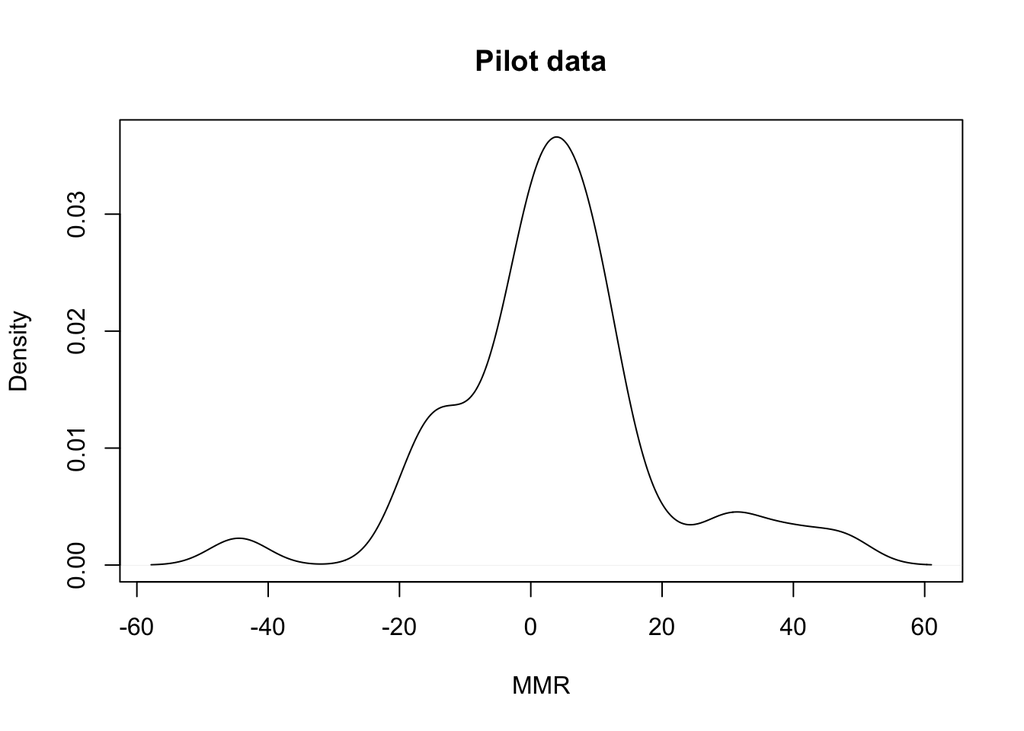

```r
plot(density(data_pilot$MMR),
     main="Pilot data",xlab="MMR")
```

```r
mean(data_pilot$MMR)
```

```
## [1] 3.546836
```

```r
sd(data_pilot$MMR)
```

```
## [1] 16.40196
```

We see that the data are normally distributed, with mean = 3.546836, SD = 16.40196

This means that we will choose a Gaussian function as the likelihood function for all models. We will check with our experimental data whether they are also normally distributed. If not, we will adapt the likelihood function accordingly.

Now we run a model with weakly informative priors. All the models in this R Markdown file are knit beforehand with the commented out code (for transparency), and are then read in (for efficiency).

```r
prior_pilot <-
  c(
    prior("normal(0, 35)", class = "Intercept"), #  weakly informative prior on intercept
    prior("normal(0, 35)", class = "b") #  weakly informative prior on slope
  )

# pilot_m = brm(MMR ~ 1 + TestSpeaker + (1 | Subj),
#                prior = prior_pilot,
#                data = data_pilot,
#                control = list(
#                  adapt_delta = .99,
#                  max_treedepth = 15),
#                file = here("data", "model_output", "02_pilot.rds")
#                )

pilot_m <- readRDS(here("data", "model_output", "02_pilot.rds"))
summary(pilot_m)
```

```
##  Family: gaussian
##   Links: mu = identity; sigma = identity
## Formula: MMR ~ 1 + TestSpeaker + (1 | Subj)
##    Data: data_pilot (Number of observations: 39)
##   Draws: 4 chains, each with iter = 2000; warmup = 1000; thin = 1;
##          total post-warmup draws = 4000
##
## Group-Level Effects:
## ~Subj (Number of levels: 13)
##               Estimate Est.Error l-95% CI u-95% CI Rhat Bulk_ESS Tail_ESS
## sd(Intercept)     5.42      3.42     0.32    12.94 1.00     1361     2054
##
## Population-Level Effects:
##              Estimate Est.Error l-95% CI u-95% CI Rhat Bulk_ESS Tail_ESS
## Intercept        3.53      3.15    -2.64     9.92 1.00     3088     2731
## TestSpeaker1     0.38      3.74    -6.97     7.68 1.00     4054     2997
## TestSpeaker2    -1.55      3.74    -9.03     5.83 1.00     4107     2394
##
## Family Specific Parameters:
##       Estimate Est.Error l-95% CI u-95% CI Rhat Bulk_ESS Tail_ESS
## sigma    16.12      2.08    12.52    20.63 1.00     2712     2707
##
## Draws were sampled using sampling(NUTS). For each parameter, Bulk_ESS
## and Tail_ESS are effective sample size measures, and Rhat is the potential
## scale reduction factor on split chains (at convergence, Rhat = 1).
```

This model estimates a mean of 3.53, and a sigma of 16.12.

We base our priors on this:

- mean = 3.5
- sigma = 20 (We add some uncertainty, so we multiply sigma by 1.25)
- we expect our effects to be smaller than 20, so we set a prior on the slope of `normal(0,10)`

giving us:

```r
priors <- c(set_prior("normal(3.5, 20)",  # sd=20 is here the SD of the distribution of the prior on mu, so how uncertain we are about the value of mu
                      class = "Intercept"),
            set_prior("normal(0, 10)",  # This is the prior on the slope
                      class = "b"),
            set_prior("normal(0, 20)",  # This is our expectation about the error in the model, so the residual noise. It's related to the overall variability in the response variable that is not captured by the predictors.
                      class = "sigma")) # brms will automatically truncate the prior specification for σ and allow only positive values (https://vasishth.github.io/bayescogsci/book/ch-reg.html), so we don't have to truncate the distribution ourselves
```

Let’s visualize the priors

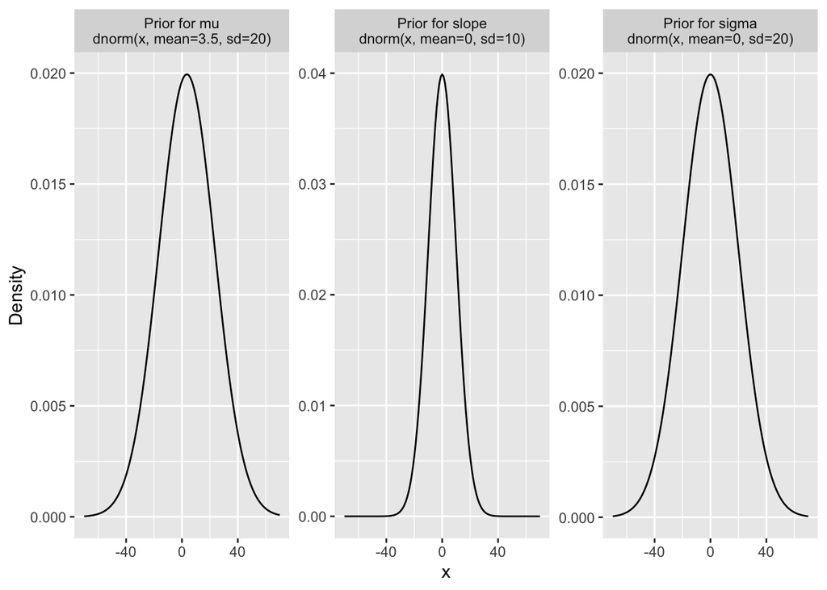

### Prior predictive checks

Here, we check what happens if we run the model based on our priors only.

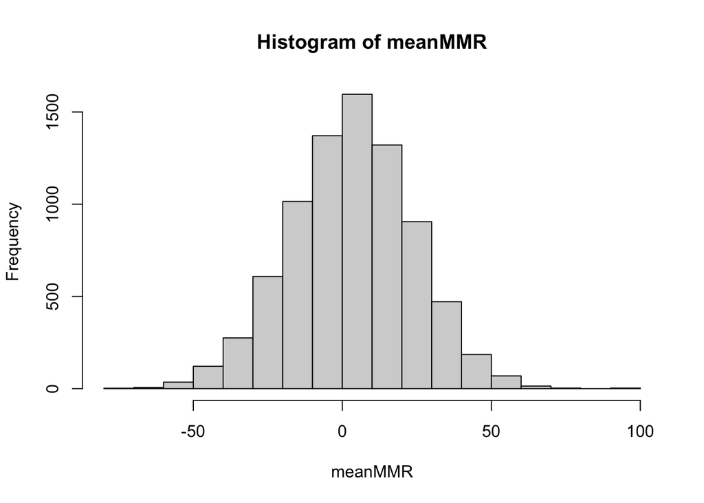

```r
# num_chains <- 4
# num_iter <- 4000
# num_warmup <- num_iter / 2
# num_thin <- 1

# priorpredcheck_rec_m <- brm(MMR ~ 1 + TestSpeaker * Group +
#                               mumDist +
#                               nrSpeakersDaily  +
#                               sleepState +
#                               age +
#                               (1 + TestSpeaker | Subj),
#                             data = dat_rec,
#                             prior = priors,
#                             family = gaussian(),
#                             control = list(
#                               adapt_delta = .99,
#                               max_treedepth = 15
#                             ),
#                             iter = num_iter,
#                             chains = num_chains,
#                             warmup = num_warmup,
#                             thin = num_thin,
#                             cores = num_chains,
#                             seed = project_seed,
#                             file = here("data", "model_output", "03_model_priorpredcheck_rec.rds"),
#                             file_refit = "on_change",
#                             save_pars = save_pars(all = TRUE),
#                             sample_prior = "only"
# )

priorpredcheck_rec_m <- readRDS(here("data", "model_output", "03_model_priorpredcheck_rec.rds"))

pp <- posterior_predict(priorpredcheck_rec_m)
pp <- t(pp)
# distribution of mean MMR
meanMMR = colMeans(pp)
hist(meanMMR, breaks = 20)
```

```r
summary(priorpredcheck_rec_m)
```

```
##  Family: gaussian
##   Links: mu = identity; sigma = identity
## Formula: MMR ~ 1 + TestSpeaker * Group + mumDist + nrSpeakersDaily + sleepState + age + (1 + TestSpeaker | Subj)
##    Data: dat_rec (Number of observations: 192)
##   Draws: 4 chains, each with iter = 4000; warmup = 2000; thin = 1;
##          total post-warmup draws = 8000
##
## Group-Level Effects:
## ~Subj (Number of levels: 64)
##                                Estimate Est.Error l-95% CI u-95% CI Rhat
## sd(Intercept)                     16.48     19.46     0.48    60.95 1.00
## sd(TestSpeaker1)                  16.89     19.54     0.46    63.80 1.00
## sd(TestSpeaker2)                  16.99     21.66     0.64    62.00 1.00
## cor(Intercept,TestSpeaker1)        0.01      0.50    -0.88     0.88 1.00
## cor(Intercept,TestSpeaker2)       -0.00      0.51    -0.88     0.88 1.00
## cor(TestSpeaker1,TestSpeaker2)    -0.00      0.49    -0.87     0.86 1.00
##                                Bulk_ESS Tail_ESS
## sd(Intercept)                      9737     3384
## sd(TestSpeaker1)                   9732     4035
## sd(TestSpeaker2)                   9972     4149
## cor(Intercept,TestSpeaker1)       13715     4869
## cor(Intercept,TestSpeaker2)       14954     5327
## cor(TestSpeaker1,TestSpeaker2)     7832     5952
##
## Population-Level Effects:
##                     Estimate Est.Error l-95% CI u-95% CI Rhat Bulk_ESS Tail_ESS
## Intercept               3.17     20.40   -37.15    42.87 1.00    14160     5979
## TestSpeaker1           -0.00      9.82   -19.24    19.28 1.00    13937     5033
## TestSpeaker2           -0.07      9.98   -19.71    19.40 1.00    12428     5904
## Group1                  0.06     10.28   -19.77    20.20 1.00    12877     6104
## mumDist                -0.03      9.86   -19.58    19.07 1.00    13679     6266
## nrSpeakersDaily        -0.12     10.09   -19.94    19.75 1.00    12855     5733
## sleepState1             0.01      9.80   -19.18    19.09 1.00    13885     5927
## age                    -0.07      9.67   -18.62    18.61 1.00    14111     6488
## TestSpeaker1:Group1     0.13     10.06   -19.48    19.96 1.00    14415     5948
## TestSpeaker2:Group1     0.13     10.06   -19.24    19.75 1.00    13172     4957
##
## Family Specific Parameters:
##       Estimate Est.Error l-95% CI u-95% CI Rhat Bulk_ESS Tail_ESS
## sigma    15.93     12.17     0.56    44.86 1.00     7356     4334
##
## Draws were sampled using sampling(NUTS). For each parameter, Bulk_ESS
## and Tail_ESS are effective sample size measures, and Rhat is the potential
## scale reduction factor on split chains (at convergence, Rhat = 1).
```

In our priors, we specified a mean of 3.5 and an SD of 20. In these plots and the model summary, we see that the mean of the MMR is estimated at 3.17 and is normally distributed, with an estimated error of 20.4. Sigma was specified at `normal(0,20)` - the estimate of 15.93 with an estimated error of 12.17 seems reasonable. The effects on the slope were specified at `normal(0,10)` which also seems to be reasonably estimated.

Conclusion: our priors seem to be reasonable.

### Posterior predictive checks

Here, we check whether our model can recover our simulated data, with our proposed priors. Our data were simulated as follows:

- mean = 5
- SD = 15
- effect of Group = 5

With the following priors:

```
priors = c(set_prior("normal(3.5, 20)",
                      class = "Intercept"),
            set_prior("normal(0, 10)",
                      class = "b"),
            set_prior("normal(0, 20)",
                      class = "sigma"))
```

We run the model with more iterations (20.000) to ensure full convergence.

```r
num_chains <- 4
num_iter <-20000
num_warmup <- num_iter / 2
num_thin <- 1
```

We also set the contrast such that we get equal priors on the different comparisons. This is important for our Bayes Factor analysis later on.

```r
contrasts(dat_rec$TestSpeaker) <- contr.equalprior_pairs
contrasts(dat_rec$Group) <- contr.equalprior_pairs
contrasts(dat_rec$sleepState) <- contr.equalprior_pairs

contrasts(dat_rec$TestSpeaker)
```

```
##   [,1]       [,2]
## 1  0.0  0.5773503
## 2 -0.5 -0.2886751
## 3  0.5 -0.2886751
```

```r
contrasts(dat_rec$Group)
```

```
##       [,1]
## fam   -0.5
## unfam  0.5
```

```r
contrasts(dat_rec$sleepState)
```

```
##        [,1]
## asleep -0.5
## awake   0.5
```

Now let’s look at the model:

```r
# postpredcheck_rec_m <- brm(MMR ~ 1 + TestSpeaker * Group +
#                             mumDist +
#                             nrSpeakersDaily +
#                             sleepState +
#                              age +
#                              (1 + TestSpeaker | Subj),
#                            data = dat_rec,
#                            prior = priors,
#                            family = gaussian(),
#                            control = list(
#                              adapt_delta = .99,
#                              max_treedepth = 15
#                            ),
#                            iter = num_iter,
#                            chains = num_chains,
#                            warmup = num_warmup,
#                            thin = num_thin,
#                            cores = num_chains,
#                            seed = project_seed,
#                            file = here("data", "model_output", "04_model_posteriorpredcheck_rec.rds"),
#                            file_refit = "on_change",
#                            save_pars = save_pars(all = TRUE)
# )

postpredcheck_rec_m <- readRDS(here("data", "model_output", "04_model_posteriorpredcheck_rec.rds"))
summary(postpredcheck_rec_m)
```

```
##  Family: gaussian
##   Links: mu = identity; sigma = identity
## Formula: MMR ~ 1 + TestSpeaker * Group + mumDist + nrSpeakersDaily + sleepState + age + (1 + TestSpeaker | Subj)
##    Data: dat_rec (Number of observations: 192)
##   Draws: 4 chains, each with iter = 20000; warmup = 10000; thin = 1;
##          total post-warmup draws = 40000
##
## Group-Level Effects:
## ~Subj (Number of levels: 64)
##                                Estimate Est.Error l-95% CI u-95% CI Rhat
## sd(Intercept)                      2.10      1.52     0.09     5.61 1.00
## sd(TestSpeaker1)                   7.86      4.65     0.41    17.23 1.00
## sd(TestSpeaker2)                  11.44      5.27     1.00    20.94 1.00
## cor(Intercept,TestSpeaker1)        0.02      0.48    -0.85     0.87 1.00
## cor(Intercept,TestSpeaker2)        0.07      0.47    -0.83     0.87 1.00
## cor(TestSpeaker1,TestSpeaker2)     0.27      0.43    -0.71     0.91 1.00
##                                Bulk_ESS Tail_ESS
## sd(Intercept)                      9689    10990
## sd(TestSpeaker1)                   6060    12117
## sd(TestSpeaker2)                   5047     9810
## cor(Intercept,TestSpeaker1)       14460    21939
## cor(Intercept,TestSpeaker2)        8116    13538
## cor(TestSpeaker1,TestSpeaker2)    10411    17120
##
## Population-Level Effects:
##                     Estimate Est.Error l-95% CI u-95% CI Rhat Bulk_ESS Tail_ESS
## Intercept               2.98      1.50     0.02     5.92 1.00    55674    30739
## TestSpeaker1            0.68      2.69    -4.62     5.95 1.00    56958    30297
## TestSpeaker2           -1.18      2.86    -6.78     4.46 1.00    52408    32113
## Group1                 -3.31      2.21    -7.63     1.03 1.00    56995    30993
## mumDist                 1.54      1.16    -0.77     3.81 1.00    38486    28749
## nrSpeakersDaily        -0.64      1.12    -2.83     1.57 1.00    55519    31742
## sleepState1             5.29      3.06    -0.74    11.28 1.00    47481    31444
## age                     1.25      1.08    -0.86     3.38 1.00    60224    29653
## TestSpeaker1:Group1   -12.58      4.90   -22.06    -2.82 1.00    60189    31556
## TestSpeaker2:Group1     1.76      5.16    -8.27    11.94 1.00    53722    29745
##
## Family Specific Parameters:
##       Estimate Est.Error l-95% CI u-95% CI Rhat Bulk_ESS Tail_ESS
## sigma    14.34      1.24    11.74    16.62 1.00     5335     5977
##
## Draws were sampled using sampling(NUTS). For each parameter, Bulk_ESS
## and Tail_ESS are effective sample size measures, and Rhat is the potential
## scale reduction factor on split chains (at convergence, Rhat = 1).
```

The model fully converged.

We can now check the values the model comes up with for the simulated data:  
b_Intercept is 2.98 (in the data it was simulated as 5, and our prior was `normal(3.5,20)`).  
It retrieves an effect of 3.31 for Group (we simulated the effect as 5).  
It also hallucinates some (small) effects for the covariates.  
Sigma is estimated at 14.34 (simulated as 15).

Now we check the traces and posterior distributions

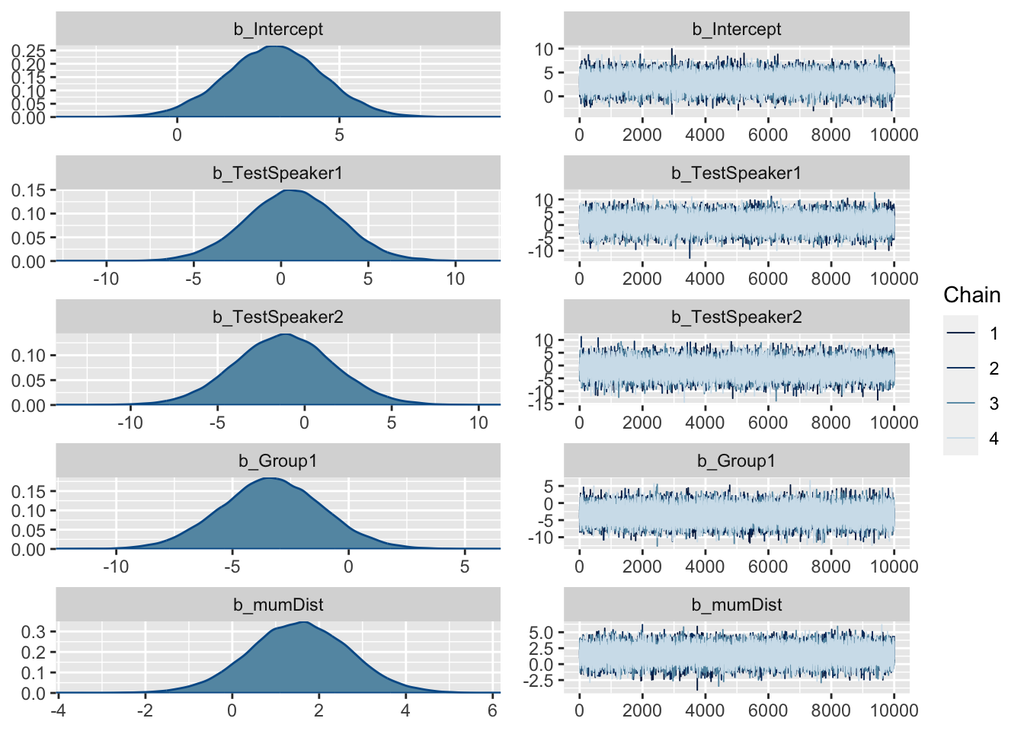

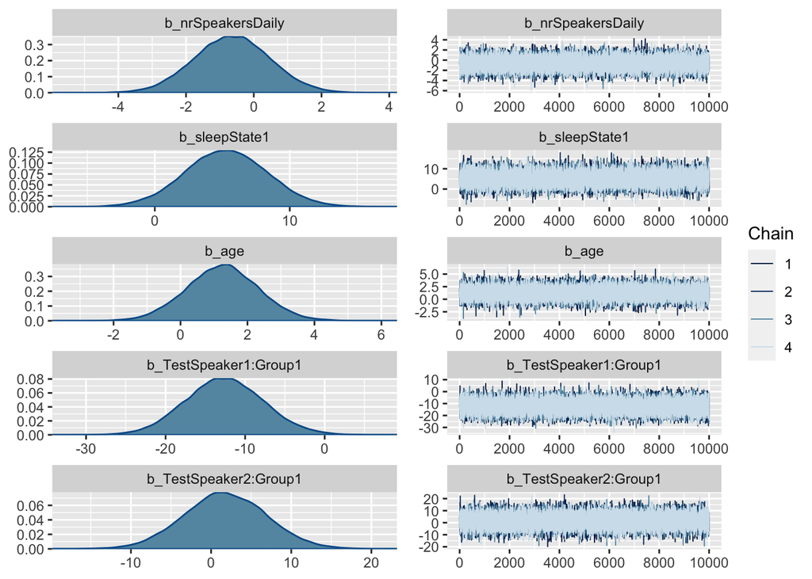

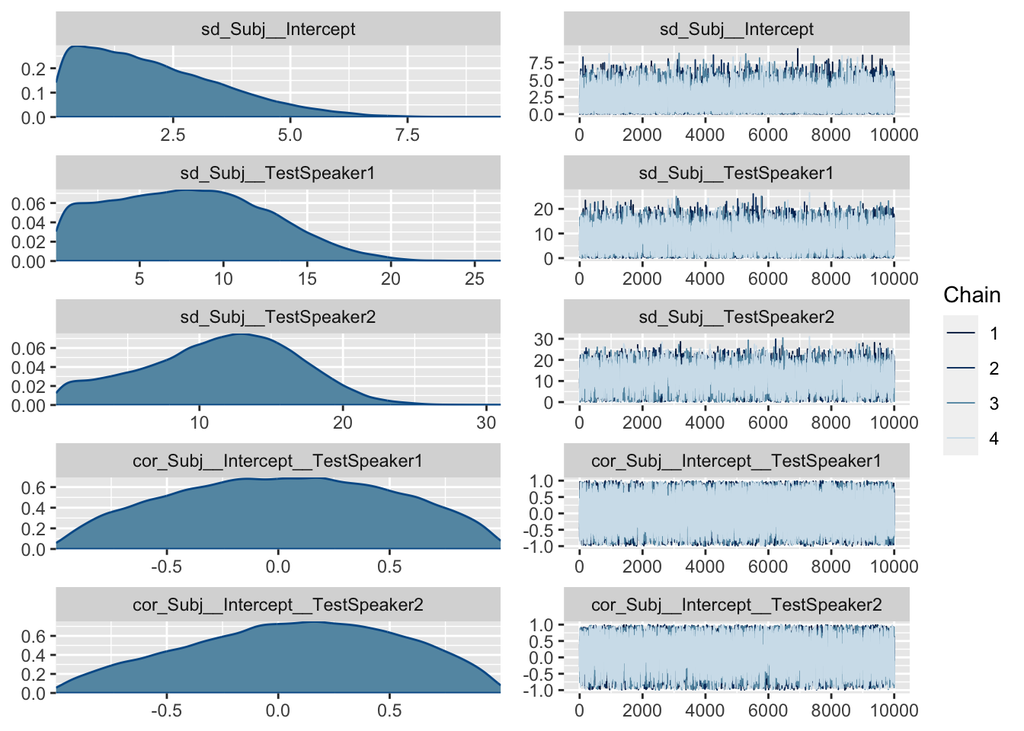

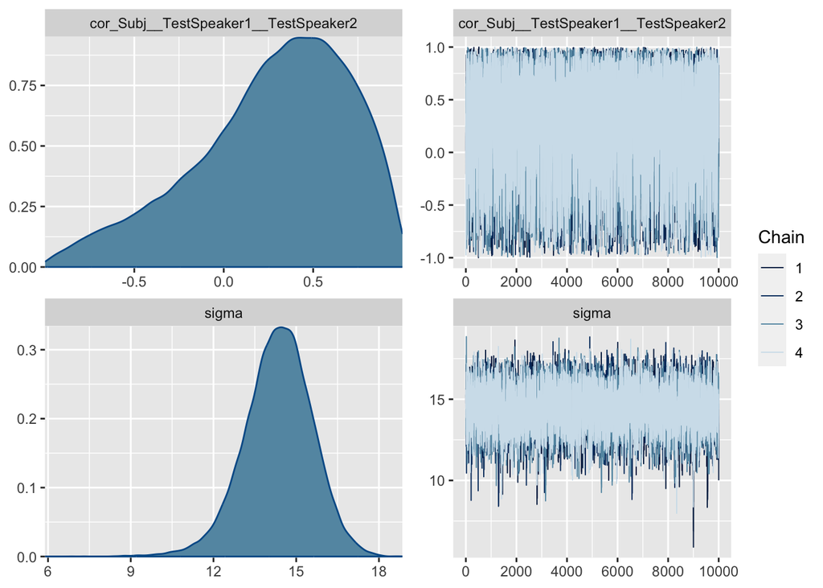

```r
plot(postpredcheck_rec_m) # check traces and posterior distributions
```

Here we see that the traces all look like nice hairy caterpillars, meaning that the chains have mixed (e.g., https://nicholasrjenkins.science/post/bda_in_r/bayes_with_brms/). The posterior distributions also look good (and we checked the estimates in the summary already).

Now we check whether the model is able to retrieve the underlying data. y is the observed data, so the data that we inputted, and y’ is the simulated data from the posterior predictive distribution.

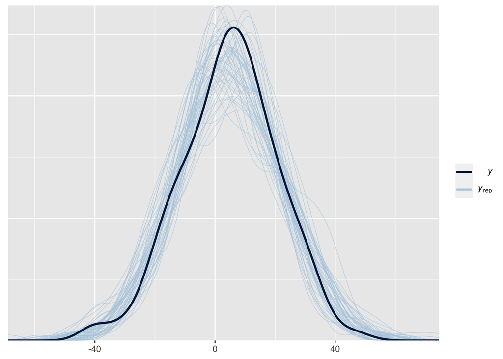

```r
pp_check(postpredcheck_rec_m, ndraws=50)
```

This looks good: the data overlap.

It thus seems as if both our priors and our model are adequate for our simulated data. We assume that this will also be the case for our experimental data. We will run the prior predictive check also for the experimental data, and the posterior predictive checks will be repeated in our model diagnostics

### Sensitivity analysis of the model’s estimates

To check how dependent the model’s estimates are on the priors, we perform a sensitivity analysis. We will check the estimates of our model with our proposed priors (intercept: `normal(3.5,20)`, slope `normal(0,10)`, sigma `normal(0,20)`), and three alternative priors:

- Alternative 1: Intercept and sigma: `normal(0,20)`, slope `normal(0,10)`: the same SD but the a mean of zero
- Alternative 2: Intercept and sigma: `normal(0,30)`, slope `normal(0,20)`: weakly informative, because of the large SD
- Alternative 3: Intercept and sigma: `normal(0,50)`, slope `normal(0,40)`: uninformative, not really biologically plausible anymore

```r
priors_orig <-
  c(set_prior("normal(3.5, 20)",
              class = "Intercept"),
    set_prior("normal(0, 10)",
              class = "b"),
    set_prior("normal(0, 20)",
              class = "sigma"))

priors1 <-
  c(set_prior("normal(0, 20)",
              class = "Intercept"),
    set_prior("normal(0, 10)",
              class = "b"),
    set_prior("normal(0, 20)",
              class = "sigma"))

priors2 <-
    c(set_prior("normal(0, 30)",
              class = "Intercept"),
    set_prior("normal(0, 20)",
              class = "b"),
    set_prior("normal(0, 30)",
              class = "sigma"))

priors3 <-
    c(set_prior("normal(0, 50)",
              class = "Intercept"),
    set_prior("normal(0, 40)",
              class = "b"),
    set_prior("normal(0, 50)",
              class = "sigma"))
```

Let’s plot these different priors for the intercept:

[figure not shown]

We ran the model of the posterior checks (see above) with these three alternative priors, such that we can compare the different estimates:

```r
m_orig <- readRDS(here("data", "model_output", "04_model_posteriorpredcheck_rec.rds"))
m_alt_1 <- readRDS(here("data", "model_output", "05_model_sensitivity_altern1_rec.rds"))
m_alt_2 <- readRDS(here("data", "model_output", "05_model_sensitivity_altern2_rec.rds"))
m_alt_3 <- readRDS(here("data", "model_output", "05_model_sensitivity_altern3_rec.rds"))

posterior_summary(m_orig, variable=c("b_Intercept","b_TestSpeaker1", "b_Group1", "sigma"))
```

```
##                  Estimate Est.Error        Q2.5     Q97.5
## b_Intercept     2.9825589  1.504505  0.01563363  5.916897
## b_TestSpeaker1  0.6833782  2.690537 -4.61596266  5.949527
## b_Group1       -3.3102205  2.207633 -7.62734155  1.033096
## sigma          14.3434494  1.242143 11.73510339 16.620188
```

```r
posterior_summary(m_alt_1, variable=c("b_Intercept","b_TestSpeaker1", "b_Group1", "sigma"))
```

```
##                  Estimate Est.Error        Q2.5     Q97.5
## b_Intercept     2.9768031  1.492489  0.04417822  5.906487
## b_TestSpeaker1  0.6661525  2.663186 -4.55201955  5.848795
## b_Group1       -3.3101291  2.217767 -7.61215934  1.072632
## sigma          14.3116564  1.232768 11.73620535 16.583558
```

```r
posterior_summary(m_alt_2, variable=c("b_Intercept","b_TestSpeaker1", "b_Group1", "sigma"))
```

```
##                  Estimate Est.Error       Q2.5      Q97.5
## b_Intercept     2.8652466  1.533799 -0.1504679  5.8416705
## b_TestSpeaker1  0.6821309  2.785749 -4.7699149  6.1152404
## b_Group1       -3.4223937  2.238056 -7.8176612  0.9689589
## sigma          14.3614699  1.253837 11.7980524 16.6413811
```

```r
posterior_summary(m_alt_3, variable=c("b_Intercept","b_TestSpeaker1", "b_Group1", "sigma"))
```

```
##                  Estimate Est.Error       Q2.5      Q97.5
## b_Intercept     2.8262507  1.535740 -0.2371199  5.8335441
## b_TestSpeaker1  0.6595579  2.781692 -4.8032430  6.0789273
## b_Group1       -3.4646494  2.261669 -7.9387088  0.9865168
## sigma          14.3870084  1.218008 11.8564896 16.6293335
```

We can now also plot different estimates for the different priors:

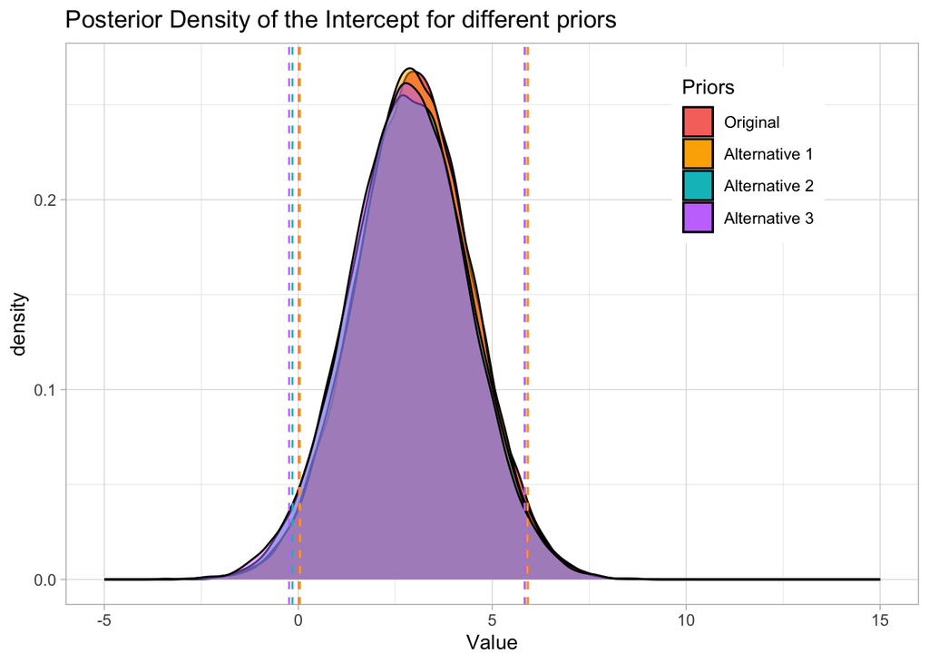

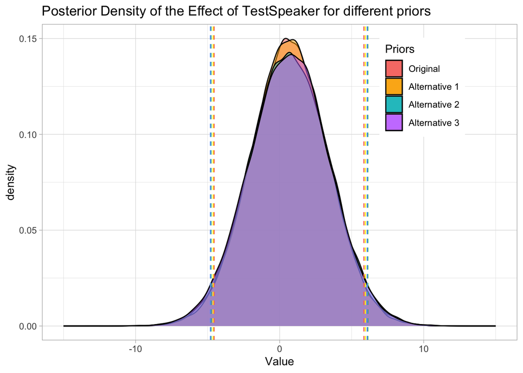

[figure not shown]

As we can see from the (plotted) estimates, the different priors barely have any effect on the estimates of the model. This means that our model is not overly sensitive to the priors.

## Analysis steps for experimental data

### Sensitivity analysis

First, we will run the same sensitivity analysis as in the last step above for our model with our experimental data.

### Parameter estimation experimental data

For the experimental data, we will use the following code for parameter estimation, assuming the same data structure as our simulated data, and the data called `dat_exp_rec`

```
# scaling the continuous predictors:
dat_exp_rec$mumDist<- scale(dat_exp_rec$mumDist)
dat_exp_rec$age <- scale(dat_exp_rec$age)
dat_exp_rec$nrSpeakersDaily <- scale(dat_exp_rec$nrSpeakersDaily)

# Setting orthogonal contrasts, such that the priors for the different contrasts we compare are orthogonal (not so important in this case since we only have 2 level factors)
contrasts(dat_exp_rec$TestSpeaker) <- contr.equalprior_pairs
contrasts(dat_exp_rec$Group) <- contr.equalprior_pairs
contrasts(dat_exp_rec$sleepState) <- contr.equalprior_pairs

# Setting up the samping:
num_chains <- 4 # number of chains = number of processor cores
num_iter <- 40000 # number of samples per chain: because I use Savage-Dickey for hypothesis testing, so we need a LOT of samples
num_warmup <- num_iter / 2 # number of warm-up samples per chain
num_thin <- 1 # thinning: extract one out of x samples per chain

# Running the model
model_rec <- brm(MMR ~ 1 + TestSpeaker * Group +
                   mumDist +
                   nrSpeakersDaily +
                   sleepState +
                   age +
                   (1 + TestSpeaker | Subj),
                 data = dat_exp_rec,
                 prior = priors,
                 family = gaussian(),
                 control = list(
                   adapt_delta = .99,
                   max_treedepth = 15
                 ),
                 iter = num_iter,
                 chains = num_chains,
                 warmup = num_warmup,
                 thin = num_thin,
                 cores = num_chains,
                 seed = project_seed,
                 file = here("data", "model_output", "A2_model_rec.rds"),
                 file_refit = "on_change",
                 save_pars = save_pars(all = TRUE)
)
```

### Model Diagnostics

We will then run some model diagnostics. First, we will plot the traces, to check model convergence, with `plot(model_rec, ask = FALSE)`. We will also check the posterior samples of the posterior predictive distribution, with

```
posterior_predict_model_rec <-
  model_rec %>%
  posterior_predict(ndraws = 2000)

PPS_rec <-
  posterior_predict_model_rec %>%
  ppc_stat_grouped(
    y = pull(dat_exp_rec, MMR),
    group = pull(dat_exp_rec, TestSpeaker_Group),
    stat = "mean"
  ) +
  ggtitle("Posterior predictive samples")
```

### Hypothesis testing

Now we want to test our hypotheses. Our main research question is: Is there a Voice Familiarity Benefit for phoneme recognition in infants?

Additional to this main questions, we will test different contrast, to address which theoretical account on the interaction between speech and voice information can best explain this benefit.

**Hypothesis 1 (directional):**  
For our main RQ, we expect that infants discriminate a vowel contrast better in groupFam-TestSpeaker1 than in groupUnfam-TestSpeaker2, shown by a more negative mismatch response (MMR; our dependent variable) in groupFam-TestSpeaker1.

**Hypothesis 2 (directional):**  
Testing the acoustic account, we expect that infants discriminate a vowel contrast better in groupUnfam-TestSpeaker3 than in groupUnfam-TestSpeaker2, shown by a more negative MMR in groupUnfam-TestSpeaker3.

**Hypothesis 3 (directional):**  
Testing the exemplar account, we expect that infants discriminate a vowel contrast better in groupUnfam-TestSpeaker1 than in groupUnfam-TestSpeaker2, shown by a more negative MMR in groupUnfam-TestSpeaker1.

**Hypothesis 4 (non-directional):**  
To test whether whether the 5-minute exposure with target vowel exemplars or naturalistic exposure to the speaker’s acoustic characteristics is more beneficial for vowel discrimination, we test the difference between groupUnfam-TestSpeaker1 than in groupUnfam-TestSpeaker3. The exemplar account would predict that infants discriminate the contrast better in groupUnfam-TestSpeaker1, shown by a more negative MMR in groupUnfam-TestSpeaker1, whereas the acoustic account predicts that infants discriminate the contrast better in groupUnfam-TestSpeaker3, shown by a more negative MMR in groupUnfam-TestSpeaker3.

We thus want the following contrasts:  
1. groupFam-TestSpeaker1 vs. groupUnfam-TestSpeaker2  
2. groupUnfam-TestSpeaker3 vs. groupUnfam-TestSpeaker2  
3. groupUnfam-TestSpeaker1 vs. groupUnfam-TestSpeaker2  
4. groupUnfam-TestSpeaker1 vs. groupUnfam-TestSpeaker3

If we find a more negative MMR for groupUnfam-TestSpeaker3 than for groupUnfam-TestSpeaker1, this could have to do with the order in the experiment: for pragmatic reasons, TestSpeaker3 was always tested last, which might lead to learning effects. We can, however, test the contrast `(unfam1 - unfam3) - (fam1 - fam3)`. If this different is significant, it shows that the order in the experiment is not only because of experimental order. The logic here is as follows: if unfam3 is more negative than unfam1, this would suggest that acoustic familiarity with the speaker (unfam3) is more helpful for vowel discrimination than having heard exemplars of the speaker without being acoustically familiar (unfam1). As mentioned above, the better discrimination for unfam3 compared to unfam1 could however also be because of experimental order. Yet, if we compare fam1 with fam3, we have a different comparison: in fam3 the infant has, just like unfam3, acoustic familiarity with the speaker but did not hear any exemplars. However, whereas unfam1 only heard exemplars without acoustic familiarity, fam1 has both examplars **and** acoustic familiarity. Therefore, the effect of acoustic familiarity is also there for fam1. We thus expect that if we find better discrimination for unfam3 compared to unfam1, this effect disappears for fam3 vs. fam1.

Bayes Factors (https://doi.org/10.3389/fpsyg.2019.02767). The Bayes factor (BF) indicates the degree by which the mass of the posterior distribution has shifted further away from or closer to the null value (0) relative to the prior distribution, thus indicating if the null hypothesis has become less or more likely given the observed data. The BF is computed as a Savage-Dickey density ratio, which is also an approximation of a Bayes factor comparing the marginal likelihoods of the model against a model in which the tested parameter has been restricted to the point-null (Wagenmakers et al., 2010).

We will use the following contrast matrix to test our contrasts:

```r
# make custom contrasts (from https://aosmith.rbind.io/2019/04/15/custom-contrasts-emmeans/)
fam1 =   c(1,0,0,0,0,0)
unfam1 = c(0,1,0,0,0,0)
fam2 =   c(0,0,1,0,0,0)
unfam2 = c(0,0,0,1,0,0)
fam3 =   c(0,0,0,0,1,0)
unfam3 = c(0,0,0,0,0,1)

custom_contrasts <- list(
  list("unfam2-fam1" = unfam2 - fam1),
  list("unfam2-unfam3" = unfam2 - unfam3),
  list("unfam2-unfam1" = unfam2 - unfam1),
  list("unfam1-unfam3" = unfam1 - unfam3)
#  ,list("(unfam1-unfam3)-(fam1-fam3)" = (unfam1 - unfam3) - (fam1 - fam3)) # this is the interaction that, if significant, shows us that a possible effect of unfam3 being more negative than unfam1 is not solely because of order in experiment.
)
```

We will use the following code to compute the pMAP:

```
## pMAP Effects Custom contrasts ------------------------

pMAP_customcontrasts_rec =
  model_rec %>%
  emmeans(~ Group:TestSpeaker) %>%
  contrast(method = custom_contrasts) %>%
  p_map() %>%
  mutate(
    "p < .05" = ifelse(p_MAP < .05, "*", "")
  )
pMAP_customcontrasts_rec
```

We will use the following code to compute the Bayes Factors:

```
model_rec_prior <- unupdate(model_rec) # sample priors from model

## Effects Custom contrasts ------------------------
# pairwise comparisons of prior distributions
customcontrasts_pairwise_prior_rec =
  model_rec_prior %>%
  emmeans(~ Group:TestSpeaker) %>% # estimated marginal means
  contrast(method = custom_contrasts)

# pairwise comparisons of posterior distributions
customcontrasts_pairwise_rec <-
  model_rec %>%
  emmeans(~ Group:TestSpeaker) %>%
  contrast(method = custom_contrasts)

# Bayes Factors (Savage-Dickey density ratio)
BF_customcontrasts_rec <-
  customcontrasts_pairwise_rec %>%
  bf_parameters(prior = customcontrasts_pairwise_prior_rec) %>%
  arrange(log_BF) # sort according to BF

# add rule-of-thumb interpretation
BF_customcontrasts_rec <-
  BF_customcontrasts_rec %>%
  add_column(
    "interpretation" = interpret_bf(
      BF_customcontrasts_rec$log_BF,
      rules = "raftery1995",
      log = TRUE,
      include_value = TRUE,
      protect_ratio = TRUE,
      exact = TRUE
    ),
    .after = "log_BF"
  )

BF_customcontrasts_rec
```

### Sensitivity analysis for Bayes Factors

As a last step, we will perform a sensitivity analysis for the BFs for each tested effect, to check in how far our BFs are dependent or our estimated effect size in our prior.

What we will most likely see is that if we assume a very low effect size (SD is low), we have support for H1, but if we assume a very big effect size (SD is very high) we find support for the H0. This is because if we assume a very low effect size (i.e., a narrow prior with low standard deviation), we are essentially saying that we expect the true effect size to be close to zero. In this case, if the observed data shows an effect that is consistent with this narrow prior, we will likely find support for the alternative hypothesis (H1). On the other hand, if we assume a very high effect size (i.e., a broad prior with high standard deviation), we are indicating that we expect a wide range of possible effect sizes, including very large ones. In this case, if the observed data does not show an effect size as large as the broad prior suggests, the Bayes Factor may favor the null hypothesis (H0), as the data is not providing strong evidence for such a large effect.

That means that we just need to describe what we see in our sensitivity analyses plots to make sure that our BFs are not solely dependent on our priors.

The code we will use for the sensitivity analysis:

```
prior_sd <- c(1, 5, 8, 10, 15, 20, 30, 40, 50)

# Run the models
for (i in 1:length(prior_sd)) {
  psd <- prior_sd[i]
  fit <- brm(MMR ~ 1 + TestSpeaker * Group +
               mumDist +
               nrSpeakersDaily +
               sleepState +
               age +
               (1 + TestSpeaker | Subj),
             data = dat_rec,
             prior = c(
               set_prior("normal(3.5, 20)", class = "Intercept"),
               set_prior(paste0("normal(0,", psd, ")"), class = "b"),
               set_prior("normal(0, 20)", class = "sigma")
             ),
             family = gaussian(),
             control = list(
               adapt_delta = .99,
               max_treedepth = 15
             ),
             iter = num_iter,
             chains = num_chains,
             warmup = num_warmup,
             thin = num_thin,
             cores = num_chains,
             seed = project_seed,
             save_pars = save_pars(all = TRUE),
             file=here("data", "sensitivity_analysis", paste0("R5_sensAnal_BF_priorsd_", psd, ".rds"))
  )
}

### Contrast 1: unfam2-fam1 -------------------------
BF <- c()
for (i in 1:length(prior_sd)) {
  psd <- prior_sd[i]
  fit <- readRDS(here("data", "sensitivity_analysis", paste0("R5_sensAnal_BF_priorsd_", psd, ".rds")))
  fit_priors <- unupdate(fit)

  m_prior <- fit_priors %>%
    emmeans(~ Group : TestSpeaker) %>%
    contrast(method = list("unfam2-fam1" = unfam2 - fam1))

  m_post <- fit %>%
    emmeans(~ Group : TestSpeaker) %>%
    contrast(method = list("unfam2-fam1" = unfam2 - fam1))

  BF_current <- bf_parameters(m_post, prior = m_prior)
  BF_current <- as.numeric(BF_current)
  BF <- c(BF, BF_current)
}

res <- data.frame(prior_sd, BF, logBF = log10(BF))
save(res, file=here("data", "sensitivity_analysis","R5_sensAnal_BF_unfam2-fam1.rda"))
#load("R5_sensAnal_BF_unfam2-fam1.rda)

breaks <- c(1 / 100, 1 / 50, 1 / 20, 1 / 10, 1 / 3, 1, 3, 5, 10, 20, 50, 100)
ggplot(res, aes(x = prior_sd, y = BF)) +
  geom_point(size = 2) +
  geom_line() +
  geom_hline(yintercept = 1, linetype = "dashed") +
  scale_x_continuous("Normal prior width (SD)\n") +
  scale_y_log10("BF10", breaks = breaks, labels = MASS::fractions(breaks)) +
  coord_cartesian(ylim = c(1 / 100, 100), xlim = c(0, tail(prior_sd, n = 1) + 40)) +
  annotate("text", x = tail(prior_sd, n = 1) + 20, y = 30, label = "Evidence in favor of H1", size = 5) +
  annotate("text", x = tail(prior_sd, n = 1) + 20, y = 1 / 30, label = "Evidence in favor of H0", size = 5) +
  theme(axis.text.y = element_text(size = 8)) +
  ggtitle("Bayes factors for unfam2-fam1")


### Contrast 2: unfam2-unfam3 -------------------------
BF <- c()
for (i in 1:length(prior_sd)) {
  psd <- prior_sd[i]
  fit <- readRDS(here("data", "sensitivity_analysis", paste0("R5_sensAnal_BF_priorsd_", psd, ".rds")))
  fit_priors <- unupdate(fit)

  m_prior <- fit_priors %>%
    emmeans(~ Group : TestSpeaker) %>%
    contrast(method = list("unfam2-unfam3" = unfam2 - unfam3))
  m_post <- fit %>%
    emmeans(~ Group : TestSpeaker) %>%
    contrast(method = list("unfam2-unfam3" = unfam2 - unfam3))

  BF_current <- bf_parameters(m_post, prior = m_prior)
  BF_current <- as.numeric(BF_current)
  BF <- c(BF, BF_current)
}

res <- data.frame(prior_sd, BF, logBF = log10(BF))
save(res, file=here("data", "sensitivity_analysis","R5_sensAnal_BF_unfam2-unfam3.rda"))
#load("R5_sensAnal_BF_unfam2-unfam3.rda)

breaks <- c(1 / 100, 1 / 50, 1 / 20, 1 / 10, 1 / 3, 1, 3, 5, 10, 20, 50, 100)
ggplot(res, aes(x = prior_sd, y = BF)) +
  geom_point(size = 2) +
  geom_line() +
  geom_hline(yintercept = 1, linetype = "dashed") +
  scale_x_continuous("Normal prior width (SD)\n") +
  scale_y_log10("BF10", breaks = breaks, labels = MASS::fractions(breaks)) +
  coord_cartesian(ylim = c(1 / 100, 100), xlim = c(0, tail(prior_sd, n = 1) + 40)) +
  annotate("text", x = tail(prior_sd, n = 1) + 20, y = 30, label = "Evidence in favor of H1", size = 5) +
  annotate("text", x = tail(prior_sd, n = 1) + 20, y = 1 / 30, label = "Evidence in favor of H0", size = 5) +
  theme(axis.text.y = element_text(size = 8)) +
  ggtitle("Bayes factors for unfam2-unfam3")


### Contrast 3: unfam2-unfam1 -------------------------
BF <- c()
for (i in 1:length(prior_sd)) {
  psd <- prior_sd[i]
  fit <- readRDS(here("data", "sensitivity_analysis", paste0("R5_sensAnal_BF_priorsd_", psd, ".rds")))
  fit_priors <- unupdate(fit)

  m_prior <- fit_priors %>%
    emmeans(~ Group : TestSpeaker) %>%
    contrast(method = list("unfam2-unfam1" = unfam2 - unfam1))
  m_post <- fit %>%
    emmeans(~ Group : TestSpeaker) %>%
    contrast(method = list("unfam2-unfam1" = unfam2 - unfam1))

  BF_current <- bf_parameters(m_post, prior = m_prior)
  BF_current <- as.numeric(BF_current)
  BF <- c(BF, BF_current)
}

res <- data.frame(prior_sd, BF, logBF = log10(BF))
save(res, file=here("data", "sensitivity_analysis","R5_sensAnal_BF_unfam2-unfam1.rda"))
#load("R5_sensAnal_BF_unfam2-unfam1.rda)

breaks <- c(1 / 100, 1 / 50, 1 / 20, 1 / 10, 1 / 3, 1, 3, 5, 10, 20, 50, 100)
ggplot(res, aes(x = prior_sd, y = BF)) +
  geom_point(size = 2) +
  geom_line() +
  geom_hline(yintercept = 1, linetype = "dashed") +
  scale_x_continuous("Normal prior width (SD)\n") +
  scale_y_log10("BF10", breaks = breaks, labels = MASS::fractions(breaks)) +
  coord_cartesian(ylim = c(1 / 100, 100), xlim = c(0, tail(prior_sd, n = 1) + 40)) +
  annotate("text", x = tail(prior_sd, n = 1) + 20, y = 30, label = "Evidence in favor of H1", size = 5) +
  annotate("text", x = tail(prior_sd, n = 1) + 20, y = 1 / 30, label = "Evidence in favor of H0", size = 5) +
  theme(axis.text.y = element_text(size = 8)) +
  ggtitle("Bayes factors for unfam2-unfam1")


### Contrast 4: unfam1-unfam3 -------------------------
BF <- c()
for (i in 1:length(prior_sd)) {
  psd <- prior_sd[i]
  fit <- readRDS(here("data", "sensitivity_analysis", paste0("R5_sensAnal_BF_priorsd_", psd, ".rds")))
  fit_priors <- unupdate(fit)

  m_prior <- fit_priors %>%
    emmeans(~ Group : TestSpeaker) %>%
    contrast(method = list("unfam1-unfam3" = unfam1 - unfam3))
  m_post <- fit %>%
    emmeans(~ Group : TestSpeaker) %>%
    contrast(method = list("unfam1-unfam3" = unfam1 - unfam3))

  BF_current <- bf_parameters(m_post, prior = m_prior)
  BF_current <- as.numeric(BF_current)
  BF <- c(BF, BF_current)
}

res <- data.frame(prior_sd, BF, logBF = log10(BF))
save(res, file=here("data", "sensitivity_analysis","R5_sensAnal_BF_unfam1-unfam3.rda"))
#load("R5_sensAnal_BF_unfam1-unfam3.rda)

breaks <- c(1 / 100, 1 / 50, 1 / 20, 1 / 10, 1 / 3, 1, 3, 5, 10, 20, 50, 100)
ggplot(res, aes(x = prior_sd, y = BF)) +
  geom_point(size = 2) +
  geom_line() +
  geom_hline(yintercept = 1, linetype = "dashed") +
  scale_x_continuous("Normal prior width (SD)\n") +
  scale_y_log10("BF10", breaks = breaks, labels = MASS::fractions(breaks)) +
  coord_cartesian(ylim = c(1 / 100, 100), xlim = c(0, tail(prior_sd, n = 1) + 40)) +
  annotate("text", x = tail(prior_sd, n = 1) + 20, y = 30, label = "Evidence in favor of H1", size = 5) +
  annotate("text", x = tail(prior_sd, n = 1) + 20, y = 1 / 30, label = "Evidence in favor of H0", size = 5) +
  theme(axis.text.y = element_text(size = 8)) +
  ggtitle("Bayes factors for unfam1-unfam3")
```